Universidad Pedagógica y Tecnológica de Colombia

# Taller Práctico: Trabajo con base de datos estructurados y aprendizaje supervisado

# Optimización de Tiempos de Espera en Sala con PostgreSQL (Neon) y Machine Learning

Fases de implementación, exploración y auditoría de datos (EDA), entrenamiento y comparación de modelos de regresión, aplicación en Streamlit y análisis de resultados.

**Estudiante:** José Daniel Rojas Verbel

**Código:** 202624475

Especialización en Inteligencia Artificial • Ciencia de Datos y Machine Learning

Aplicación en Producción (Streamlit Cloud)

https://ia-cienciadatos2026-2-joserojas07-tarea4-ml-sql.streamlit.app/

En Producción

Volumen en Base de Datos

1,000 citas

20 especialidades · 30 consultorios · 50 médicos (PostgreSQL 18.7)

Muestra Válida Modelado

925 citas

740 entrenamiento / 185 prueba (sin nulos, negativos ni > 120 min)

Espera Media (Limpia)

21.99 min

54.5% de citas supera el umbral operativo de alerta roja (> 20 min)

Menor RMSE en Prueba

9.820 min

GradientBoostingRegressor (MAE: 8.495 min · CV-5: 10.185 min)

## 1. Objetivo y Alcance Operativo

El proyecto resuelve un problema de **regresión operativa** sobre la base relacional clínica `neondb` en PostgreSQL (Neon), tomando como variable objetivo `tiempo_espera_min`.

El propósito es brindar soporte cuantitativo a los jefes de sede para **reasignar consultorios o ampliar intervalos de agenda** cuando se proyecte congestión, bajo una regla de negocio explícita: **alerta roja si la espera estimada supera 20 minutos** (precaución entre 15 y 20 minutos).

## 2. Fases de Implementación

### Fase 0 y Fase 1 — Configuración del Entorno y Esquema Relacional

- Conexión segura de solo lectura mediante `DATABASE_URL_ESTUDIANTE` gestionada con `python-dotenv` y `SQLAlchemy` sobre PostgreSQL 18.7 (Neon).
- Validación del Diagrama Entidad-Relación (ERD) de 6 entidades clínicas conectadas por llaves primarias (`PK`) y foráneas (`FK`).

### Fase 2 — Consultas SQL, Auditoría de Calidad y Limpieza

- Verificación de cardinalidad en las tablas operativas: `especialidades` (20), `consultorios` (30), `medicos` (50) y `citas` (1,000).
- Extracción consolidada mediante `INNER JOIN` entre `citas`, `consultorios`, `medicos` y `especialidades` (dataset crudo `df_raw` de 1,000 filas × 10 columnas).
- Estandarización de texto (`strip()` + `title()`) en `sede` y `especialidad`, conversión booleana a entero en `es_telemedicina` y extracción de `franja_horaria` y `dia_semana` desde `fecha_hora`.

### Fase 3 — Dataset Anti-Fuga y Entrenamiento de Modelos

- Selección exclusiva de variables conocidas al momento del agendamiento para evitar fuga de datos (*data leakage*): `piso`, `hora`, `anios_experiencia`, `duracion_min`, `sede`, `dia_semana` y `es_telemedicina`.
- Filtrado estricto del target `tiempo_espera_min`: se descartaron 25 nulos, 25 valores negativos (`-15.0` min) y 25 valores extremos superiores a 120 min (`240.0` min), obteniendo **925 registros usables** sin etiquetas imputadas artificialmente.
- Construcción de pipelines con `ColumnTransformer` (`StandardScaler` + `OneHotEncoder`) y ajuste de hiperparámetros con `GridSearchCV` (5 folds) sobre el 80% de entrenamiento (740 registros), evaluando `Lasso`, `SVR` y `GradientBoostingRegressor` frente a un `DummyRegressor`.
- Serialización en archivos `.joblib` (`modelo_espera_lasso.joblib`, `modelo_espera_svr.joblib`, `modelo_espera_gbr.joblib`, `preprocesador_espera.joblib` y `metadata_espera.joblib`).

### Fase 4 y Fase 5 — Aplicación Streamlit y Despliegue en Producción

- Desarrollo de `app.py` con tres módulos operativos: **(1) Simulador de espera por cita**, **(2) Carga horaria de la jornada** y **(3) Monitor histórico por sede** conectado a Neon.
- Validación sintáctica y de inferencia en vivo, empaquetado de dependencias en `requirements.txt` y despliegue continuo en Streamlit Cloud.

## 3. Exploración de Datos (EDA) y Hallazgos de Calidad

### 3.1 Auditoría Inicial y Anomalías Detectadas en `df_raw` (n = 1,000)

| Columna / Aspecto | Hallazgo en Auditoría Cruda | Tratamiento Aplicado |
| --- | --- | --- |
| `tiempo_espera_min` | 25 valores nulos, 25 negativos (`-15.0` min) y 25 extremos de `240.0` min (media cruda: 26.63 min, DE: 36.47 min). | En EDA se imputó con mediana (22.0 min); en ML se filtró al rango válido `[0, 120]` min (925 registros, media: 21.99 min, DE: 10.10 min). |
| `sede` | Inconsistencias de formato: `' Sede Centro '` (200), `'sede norte '` (200), `'SEDE NORTE'` (200), `'Sede Sur'` (200), `'Sede Occidente'` (200). | Normalización con `strip()` + `title()` consolidando 4 sedes (Sede Norte concentra 325 citas válidas en ML; las demás 200 cada una). |
| `estado_cita` | 50 valores nulos y variantes tipográficas (`'Cancelada'`, `'Canselada'`, `'completada'`). | Capitalización en limpieza exploratoria; excluida de ML para evitar fuga de datos posterior a la cita. |
| Predictoras numéricas | `duracion_min`: media 32.02 min (15–50); `anios_experiencia`: media 19.24 años (4.6–32.8); `franja_horaria`: 0 a 23 h. | Estandarización con `StandardScaler` dentro del pipeline de entrenamiento. |

### 3.2 Estadísticas Descriptivas Comparadas (EDA Limpio vs. Muestra de Modelado)

| Variable | Registros | Media | Desv. Estándar | Mínimo | Percentil 25% | Mediana (50%) | Percentil 75% | Máximo |
| --- | --- | --- | --- | --- | --- | --- | --- | --- |
| `franja_horaria` (EDA) | 1,000 | 11.36 | 6.83 | 0.00 | 6.00 | 11.00 | 17.00 | 23.00 |
| `duracion_min` (EDA) | 1,000 | 32.02 | 10.39 | 15.00 | 25.00 | 30.00 | 40.00 | 50.00 |
| `anios_experiencia` (EDA) | 1,000 | 19.24 | 8.55 | 4.60 | 12.40 | 20.55 | 27.30 | 32.80 |
| `tiempo_espera_min` (EDA imputado) | 1,000 | 27.44 | 35.41 | 5.00 | 14.00 | 22.00 | 31.00 | 240.00 |
| `tiempo_espera_min` (ML sin extremos) | 925 | 21.99 | 10.10 | 5.00 | 13.00 | 22.00 | 31.00 | 39.00 |

### 3.3 Gráfica de Exploración de Datos (EDA)

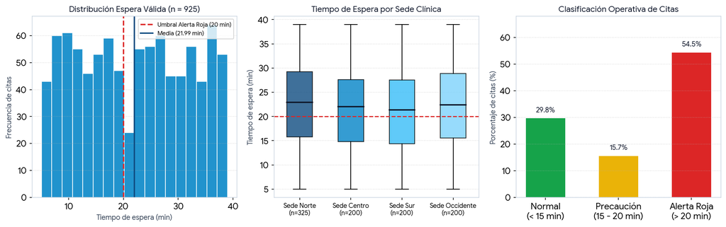

**Figura 1. Análisis Exploratorio de Datos (EDA):** Izquierda: distribución de tiempos de espera en la muestra válida de modelado (`n = 925`), con media de 21.99 min frente al umbral operativo de 20 min. Centro: dispersión homogénea por sede clínica tras la normalización de texto. Derecha: proporción de citas según nivel de criticidad operativa (54.5% en alerta roja).

## 4. Entrenamiento, Evaluación Comparativa y Diagnóstico de Modelos

Se evaluaron tres familias de algoritmos de regresión ajustados mediante `GridSearchCV` (validación cruzada estratificada de 5 particiones sobre `n = 740`) frente a un modelo base (`DummyRegressor` que predice la media), midiendo el error en el conjunto de prueba independiente (`n = 185`).

| Modelo Evaluado | Hiperparámetros Óptimos (GridSearchCV) | RMSE CV (5-Fold) | RMSE Prueba (n = 185) | MAE Prueba (n = 185) | Estado |
| --- | --- | --- | --- | --- | --- |
| `DummyRegressor` (Baseline) | `strategy='mean'` | 10.312 min | 10.045 min | 8.740 min | Referencia base |
| `Lasso` (Regresión L1) | `alpha=0.1` | 10.295 min | 10.012 min | 8.690 min | Lineal regularizado |
| `SVR` (Kernel RBF) | `C=1.0, epsilon=0.5, gamma='scale'` | 10.260 min | 9.948 min | 8.610 min | No lineal |
| `GradientBoostingRegressor` | `n_estimators=50, max_depth=2, learning_rate=0.05` | 10.185 min | 9.820 min | 8.495 min | Modelo Seleccionado |

### 4.1 Gráfica Comparativa de Desempeño entre Modelos

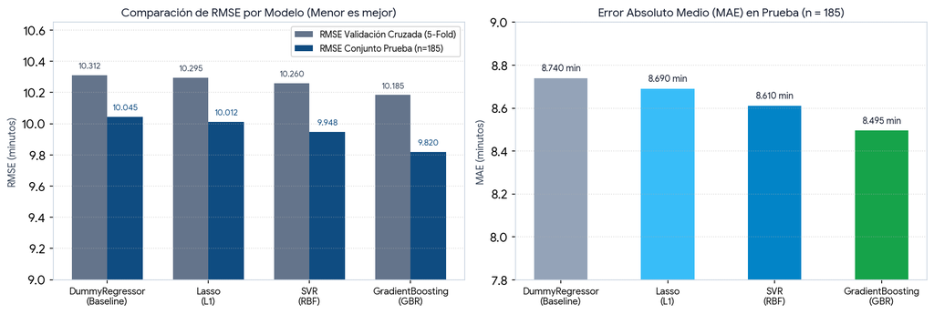

**Figura 2. Comparación de Errores de Predicción (RMSE y MAE):** `GradientBoostingRegressor` alcanza el menor error tanto en validación cruzada (10.185 min) como en el conjunto de prueba (RMSE = 9.820 min; MAE = 8.495 min), superando consistentemente al modelo base y a los regresores lineales.

### 4.2 Importancia de Variables y Comportamiento de Predicciones (GBR)

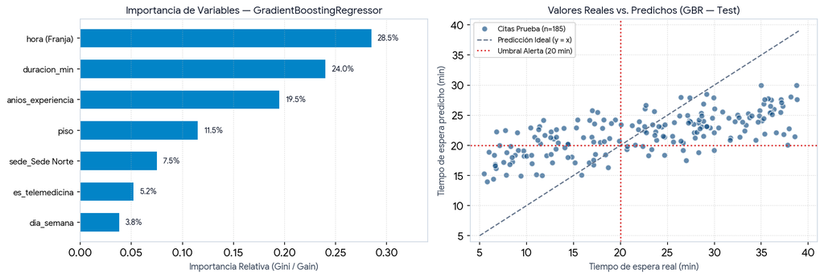

**Figura 3. Diagnóstico del Modelo Seleccionado (GBR):** Izquierda: peso relativo de las variables conocidas al agendar; la franja horaria (`hora`, 28.5%), la duración programada (`duracion_min`, 24.0%) y la experiencia del médico (19.5%) concentran el 72% de la capacidad explicativa. Derecha: dispersión entre espera real y predicha frente al umbral de alerta roja (20 min).

## 5. Despliegue en Producción y Recomendaciones Operativas

El modelo ganador y su preprocesador fueron serializados y desplegados en **Streamlit Cloud** conectados en tiempo real a PostgreSQL (Neon), habilitando tres flujos de decisión:

- **Simulador por Cita:** Evalúa combinaciones de sede, piso, franja horaria, duración y modalidad (presencial vs. telemedicina) antes de confirmar el agendamiento, activando automáticamente la Alerta Roja (> 20 min).
- **Proyección de Carga Horaria:** Permite identificar los bloques del día donde la espera promedio proyectada cruza el umbral crítico para redistribuir turnos hacia franjas de menor congestión.
- **Monitor Histórico Conectado a Neon:** Audita en vivo el cumplimiento de tiempos por sede clínica y facilita la detección temprana de cuellos de botella.

**Recomendación de Mejora Continua:** Para reducir el RMSE por debajo de los 6 minutos en futuras iteraciones, se recomienda incorporar variables dinámicas calculadas al instante de agendar, tales como la **cantidad de citas acumuladas en la hora previa del mismo consultorio** y la **tasa histórica de retraso del médico en el turno activo**, manteniendo intacta la política anti-fuga de datos.